# Project: Investigate a Dataset (Appointment data)

Is there a relationship between the patient’s gender and attending the appointment or not ?

What is the average age by gender for those attending the appointment ?

What is the most age group that attended the appointment, as well as the most age group that did not attend ?

What is the total number of patients who attended the appointment ?

- Introduction
- Data Wrangling
- Exploratory Data Analysis
- Conclusions

```python
import pandas as pd
import matplotlib.pyplot as plt
import numpy as np
import seaborn as sns
%matplotlib inline
```

## Data Wrangling

### General Properties

```python
# Load dataset and print out a few lines.
df=pd.read_csv('Appointment data.csv')
df.head()
```

|  | PatientId | AppointmentID | Gender | ScheduledDay | AppointmentDay | Age | Neighbourhood | Scholarship | Hipertension | Diabetes | Alcoholism | Handcap | SMS_received | No-show |
| --- | --- | --- | --- | --- | --- | --- | --- | --- | --- | --- | --- | --- | --- | --- |
| 0 | 2.987250e+13 | 5642903 | F | 2016-04-29T18:38:08Z | 2016-04-29T00:00:00Z | 62 | JARDIM DA PENHA | 0 | 1 | 0 | 0 | 0 | 0 | No |
| 1 | 5.589978e+14 | 5642503 | M | 2016-04-29T16:08:27Z | 2016-04-29T00:00:00Z | 56 | JARDIM DA PENHA | 0 | 0 | 0 | 0 | 0 | 0 | No |
| 2 | 4.262962e+12 | 5642549 | F | 2016-04-29T16:19:04Z | 2016-04-29T00:00:00Z | 62 | MATA DA PRAIA | 0 | 0 | 0 | 0 | 0 | 0 | No |
| 3 | 8.679512e+11 | 5642828 | F | 2016-04-29T17:29:31Z | 2016-04-29T00:00:00Z | 8 | PONTAL DE CAMBURI | 0 | 0 | 0 | 0 | 0 | 0 | No |
| 4 | 8.841186e+12 | 5642494 | F | 2016-04-29T16:07:23Z | 2016-04-29T00:00:00Z | 56 | JARDIM DA PENHA | 0 | 1 | 1 | 0 | 0 | 0 | No |

```python
#check for structured data
df.info()
```

```
<class 'pandas.core.frame.DataFrame'>
RangeIndex: 110527 entries, 0 to 110526
Data columns (total 14 columns):
PatientId         110527 non-null float64
AppointmentID     110527 non-null int64
Gender            110527 non-null object
ScheduledDay      110527 non-null object
AppointmentDay    110527 non-null object
Age               110527 non-null int64
Neighbourhood     110527 non-null object
Scholarship       110527 non-null int64
Hipertension      110527 non-null int64
Diabetes          110527 non-null int64
Alcoholism        110527 non-null int64
Handcap           110527 non-null int64
SMS_received      110527 non-null int64
No-show           110527 non-null object
dtypes: float64(1), int64(8), object(5)
memory usage: 11.8+ MB
```

```python
df.shape
```

```
(110527, 14)
```

```python
#drop unnecessary columns
df.drop(['ScheduledDay','AppointmentDay'],axis=1,inplace=True)
df.head()
```

|  | PatientId | AppointmentID | Gender | Age | Neighbourhood | Scholarship | Hipertension | Diabetes | Alcoholism | Handcap | SMS_received | No-show |
| --- | --- | --- | --- | --- | --- | --- | --- | --- | --- | --- | --- | --- |
| 0 | 2.987250e+13 | 5642903 | F | 62 | JARDIM DA PENHA | 0 | 1 | 0 | 0 | 0 | 0 | No |
| 1 | 5.589978e+14 | 5642503 | M | 56 | JARDIM DA PENHA | 0 | 0 | 0 | 0 | 0 | 0 | No |
| 2 | 4.262962e+12 | 5642549 | F | 62 | MATA DA PRAIA | 0 | 0 | 0 | 0 | 0 | 0 | No |
| 3 | 8.679512e+11 | 5642828 | F | 8 | PONTAL DE CAMBURI | 0 | 0 | 0 | 0 | 0 | 0 | No |
| 4 | 8.841186e+12 | 5642494 | F | 56 | JARDIM DA PENHA | 0 | 1 | 1 | 0 | 0 | 0 | No |

```python
df.describe()
```

|  | PatientId | AppointmentID | Age | Scholarship | Hipertension | Diabetes | Alcoholism | Handcap | SMS_received |
| --- | --- | --- | --- | --- | --- | --- | --- | --- | --- |
| count | 1.105270e+05 | 1.105270e+05 | 110527.000000 | 110527.000000 | 110527.000000 | 110527.000000 | 110527.000000 | 110527.000000 | 110527.000000 |
| mean | 1.474963e+14 | 5.675305e+06 | 37.088874 | 0.098266 | 0.197246 | 0.071865 | 0.030400 | 0.022248 | 0.321026 |
| std | 2.560949e+14 | 7.129575e+04 | 23.110205 | 0.297675 | 0.397921 | 0.258265 | 0.171686 | 0.161543 | 0.466873 |
| min | 3.921784e+04 | 5.030230e+06 | -1.000000 | 0.000000 | 0.000000 | 0.000000 | 0.000000 | 0.000000 | 0.000000 |
| 25% | 4.172614e+12 | 5.640286e+06 | 18.000000 | 0.000000 | 0.000000 | 0.000000 | 0.000000 | 0.000000 | 0.000000 |
| 50% | 3.173184e+13 | 5.680573e+06 | 37.000000 | 0.000000 | 0.000000 | 0.000000 | 0.000000 | 0.000000 | 0.000000 |
| 75% | 9.439172e+13 | 5.725524e+06 | 55.000000 | 0.000000 | 0.000000 | 0.000000 | 0.000000 | 0.000000 | 1.000000 |
| max | 9.999816e+14 | 5.790484e+06 | 115.000000 | 1.000000 | 1.000000 | 1.000000 | 1.000000 | 4.000000 | 1.000000 |

```python
df['Age'].value_counts()
```

```
 0      3539
 1      2273
 52     1746
 49     1652
 53     1651
 56     1635
 38     1629
 59     1624
 2      1618
 50     1613
 57     1603
 36     1580
 51     1567
 19     1545
 39     1536
```

[output cut: 47 more lines]

```python
#fix the problem of the incorrect age entrance by replacing it in the average age of patients.
new_value=df['Age'].mean()
df.replace(-1,new_value, inplace=True)
```

```python
df['Age'].value_counts()
```

```
0.000000      3539
1.000000      2273
52.000000     1746
49.000000     1652
53.000000     1651
56.000000     1635
38.000000     1629
59.000000     1624
2.000000      1618
50.000000     1613
57.000000     1603
36.000000     1580
51.000000     1567
19.000000     1545
39.000000     1536
37.000000     1533
54.000000     1530
34.000000     1526
33.000000     1524
30.000000     1521
6.000000      1521
3.000000      1513
17.000000     1509
32.000000     1505
5.000000      1489
18.000000     1487
44.000000     1487
58.000000     1469
46.000000     1460
45.000000     1453
              ...
74.000000      602
76.000000      571
75.000000      544
78.000000      541
77.000000      527
80.000000      511
81.000000      434
82.000000      392
79.000000      390
84.000000      311
83.000000      280
85.000000      275
86.000000      260
87.000000      184
89.000000      173
88.000000      126
90.000000      109
92.000000       86
91.000000       66
93.000000       53
94.000000       33
95.000000       24
96.000000       17
97.000000       11
98.000000        6
115.000000       5
100.000000       4
102.000000       2
37.088874        1
99.000000        1
Name: Age, Length: 104, dtype: int64
```

### Data Cleaning:

check for duplicate data

check for missed data

```python
print(df.duplicated().sum())
```

```
0
```

```python
df.count()
#No missing or duplicate data.
```

```
PatientId        110527
AppointmentID    110527
Gender           110527
Age              110527
Neighbourhood    110527
Scholarship      110527
Hipertension     110527
Diabetes         110527
Alcoholism       110527
Handcap          110527
SMS_received     110527
No-show          110527
dtype: int64
```

```python
df.rename(columns=lambda x: x.strip().lower().replace("-", "_"), inplace=True)
#change type of no_show to become int
#In the original dataset No mean that he attended, and yes means that he did not attend
#after change  the type of no_show, one mean he attended and zero he doesn't
df['noo_show'] = np.where(df['no_show'] == 'Yes', 0, 1)
df
df['genderr'] = np.where(df['gender'] == 'M', 0, 1)
df
```

|  | patientid | appointmentid | gender | age | neighbourhood | scholarship | hipertension | diabetes | alcoholism | handcap | sms_received | no_show | noo_show | genderr |
| --- | --- | --- | --- | --- | --- | --- | --- | --- | --- | --- | --- | --- | --- | --- |
| 0 | 2.987250e+13 | 5642903 | F | 62.0 | JARDIM DA PENHA | 0 | 1 | 0 | 0 | 0 | 0 | No | 1 | 1 |
| 1 | 5.589978e+14 | 5642503 | M | 56.0 | JARDIM DA PENHA | 0 | 0 | 0 | 0 | 0 | 0 | No | 1 | 0 |
| 2 | 4.262962e+12 | 5642549 | F | 62.0 | MATA DA PRAIA | 0 | 0 | 0 | 0 | 0 | 0 | No | 1 | 1 |
| 3 | 8.679512e+11 | 5642828 | F | 8.0 | PONTAL DE CAMBURI | 0 | 0 | 0 | 0 | 0 | 0 | No | 1 | 1 |
| 4 | 8.841186e+12 | 5642494 | F | 56.0 | JARDIM DA PENHA | 0 | 1 | 1 | 0 | 0 | 0 | No | 1 | 1 |
| 5 | 9.598513e+13 | 5626772 | F | 76.0 | REPÚBLICA | 0 | 1 | 0 | 0 | 0 | 0 | No | 1 | 1 |
| 6 | 7.336882e+14 | 5630279 | F | 23.0 | GOIABEIRAS | 0 | 0 | 0 | 0 | 0 | 0 | Yes | 0 | 1 |
| 7 | 3.449833e+12 | 5630575 | F | 39.0 | GOIABEIRAS | 0 | 0 | 0 | 0 | 0 | 0 | Yes | 0 | 1 |
| 8 | 5.639473e+13 | 5638447 | F | 21.0 | ANDORINHAS | 0 | 0 | 0 | 0 | 0 | 0 | No | 1 | 1 |
| 9 | 7.812456e+13 | 5629123 | F | 19.0 | CONQUISTA | 0 | 0 | 0 | 0 | 0 | 0 | No | 1 | 1 |
| 10 | 7.345362e+14 | 5630213 | F | 30.0 | NOVA PALESTINA | 0 | 0 | 0 | 0 | 0 | 0 | No | 1 | 1 |
| 11 | 7.542951e+12 | 5620163 | M | 29.0 | NOVA PALESTINA | 0 | 0 | 0 | 0 | 0 | 1 | Yes | 0 | 0 |
| 12 | 5.666548e+14 | 5634718 | F | 22.0 | NOVA PALESTINA | 1 | 0 | 0 | 0 | 0 | 0 | No | 1 | 1 |
| 13 | 9.113946e+14 | 5636249 | M | 28.0 | NOVA PALESTINA | 0 | 0 | 0 | 0 | 0 | 0 | No | 1 | 0 |
| 14 | 9.988472e+13 | 5633951 | F | 54.0 | NOVA PALESTINA | 0 | 0 | 0 | 0 | 0 | 0 | No | 1 | 1 |
| 15 | 9.994839e+10 | 5620206 | F | 15.0 | NOVA PALESTINA | 0 | 0 | 0 | 0 | 0 | 1 | No | 1 | 1 |
| 16 | 8.457439e+13 | 5633121 | M | 50.0 | NOVA PALESTINA | 0 | 0 | 0 | 0 | 0 | 0 | No | 1 | 0 |
| 17 | 1.479497e+13 | 5633460 | F | 40.0 | CONQUISTA | 1 | 0 | 0 | 0 | 0 | 0 | Yes | 0 | 1 |
| 18 | 1.713538e+13 | 5621836 | F | 30.0 | NOVA PALESTINA | 1 | 0 | 0 | 0 | 0 | 1 | No | 1 | 1 |
| 19 | 7.223289e+12 | 5640433 | F | 46.0 | DA PENHA | 0 | 0 | 0 | 0 | 0 | 0 | No | 1 | 1 |
| 20 | 6.222575e+14 | 5626083 | F | 30.0 | NOVA PALESTINA | 0 | 0 | 0 | 0 | 0 | 0 | Yes | 0 | 1 |
| 21 | 1.215484e+13 | 5628338 | F | 4.0 | CONQUISTA | 0 | 0 | 0 | 0 | 0 | 0 | Yes | 0 | 1 |
| 22 | 8.632298e+14 | 5616091 | M | 13.0 | CONQUISTA | 0 | 0 | 0 | 0 | 0 | 1 | Yes | 0 | 0 |
| 23 | 2.137540e+14 | 5634142 | F | 46.0 | CONQUISTA | 0 | 0 | 0 | 0 | 0 | 0 | No | 1 | 1 |
| 24 | 8.734858e+12 | 5641780 | F | 65.0 | TABUAZEIRO | 0 | 0 | 0 | 0 | 0 | 0 | No | 1 | 1 |
| 25 | 5.819370e+12 | 5624020 | M | 46.0 | CONQUISTA | 0 | 1 | 0 | 0 | 0 | 1 | No | 1 | 0 |
| 26 | 2.578785e+10 | 5641781 | F | 45.0 | BENTO FERREIRA | 0 | 1 | 0 | 0 | 0 | 0 | No | 1 | 1 |
| 27 | 1.215484e+13 | 5628345 | F | 4.0 | CONQUISTA | 0 | 0 | 0 | 0 | 0 | 0 | No | 1 | 1 |
| 28 | 5.926172e+12 | 5642400 | M | 51.0 | SÃO PEDRO | 0 | 0 | 0 | 0 | 0 | 0 | No | 1 | 0 |
| 29 | 1.225776e+12 | 5642186 | F | 32.0 | SANTA MARTHA | 0 | 0 | 0 | 0 | 0 | 0 | No | 1 | 1 |
| ... | ... | ... | ... | ... | ... | ... | ... | ... | ... | ... | ... | ... | ... | ... |
| 110497 | 7.935892e+14 | 5757745 | M | 76.0 | MARIA ORTIZ | 0 | 0 | 0 | 0 | 0 | 0 | No | 1 | 0 |
| 110498 | 9.433654e+13 | 5787655 | F | 59.0 | MARIA ORTIZ | 0 | 0 | 0 | 0 | 0 | 0 | No | 1 | 1 |
| 110499 | 8.219692e+14 | 5757697 | F | 66.0 | MARIA ORTIZ | 0 | 1 | 1 | 0 | 0 | 0 | No | 1 | 1 |
| 110500 | 4.434384e+14 | 5787233 | F | 59.0 | MARIA ORTIZ | 0 | 0 | 0 | 0 | 0 | 0 | No | 1 | 1 |
| 110501 | 4.544252e+11 | 5758133 | M | 44.0 | MARIA ORTIZ | 0 | 0 | 0 | 0 | 0 | 0 | No | 1 | 0 |
| 110502 | 7.316229e+14 | 5787937 | F | 22.0 | GOIABEIRAS | 0 | 0 | 0 | 0 | 0 | 0 | No | 1 | 1 |
| 110503 | 2.362182e+13 | 5759473 | F | 64.0 | SOLON BORGES | 0 | 0 | 0 | 0 | 0 | 0 | No | 1 | 1 |
| 110504 | 9.947983e+12 | 5788052 | F | 4.0 | MARIA ORTIZ | 0 | 0 | 0 | 0 | 0 | 0 | No | 1 | 1 |
| 110505 | 5.667344e+13 | 5758455 | F | 55.0 | MARIA ORTIZ | 0 | 0 | 0 | 0 | 0 | 0 | No | 1 | 1 |
| 110506 | 8.973883e+11 | 5758779 | M | 5.0 | MARIA ORTIZ | 0 | 0 | 0 | 0 | 0 | 0 | No | 1 | 0 |
| 110507 | 4.769462e+14 | 5786918 | F | 0.0 | MARIA ORTIZ | 0 | 0 | 0 | 0 | 0 | 0 | No | 1 | 1 |
| 110508 | 9.433654e+13 | 5757656 | F | 59.0 | MARIA ORTIZ | 0 | 0 | 0 | 0 | 0 | 0 | No | 1 | 1 |
| 110509 | 4.952968e+14 | 5786750 | M | 33.0 | MARIA ORTIZ | 0 | 0 | 0 | 0 | 0 | 0 | No | 1 | 0 |
| 110510 | 2.362182e+13 | 5757587 | F | 64.0 | SOLON BORGES | 0 | 0 | 0 | 0 | 0 | 0 | No | 1 | 1 |
| 110511 | 8.235996e+11 | 5786742 | F | 14.0 | MARIA ORTIZ | 0 | 0 | 0 | 0 | 0 | 0 | No | 1 | 1 |
| 110512 | 9.876246e+13 | 5786368 | F | 41.0 | MARIA ORTIZ | 0 | 0 | 0 | 0 | 0 | 0 | No | 1 | 1 |
| 110513 | 8.674778e+13 | 5785964 | M | 2.0 | ANTÔNIO HONÓRIO | 0 | 0 | 0 | 0 | 0 | 0 | No | 1 | 0 |
| 110514 | 2.695685e+12 | 5786567 | F | 58.0 | MARIA ORTIZ | 0 | 0 | 0 | 0 | 0 | 0 | No | 1 | 1 |
| 110515 | 6.456342e+14 | 5778621 | M | 33.0 | MARIA ORTIZ | 0 | 1 | 0 | 0 | 0 | 0 | Yes | 0 | 0 |
| 110516 | 6.923772e+13 | 5780205 | F | 37.0 | MARIA ORTIZ | 0 | 0 | 0 | 0 | 0 | 0 | Yes | 0 | 1 |
| 110517 | 5.574942e+12 | 5780122 | F | 19.0 | MARIA ORTIZ | 0 | 0 | 0 | 0 | 0 | 0 | No | 1 | 1 |
| 110518 | 7.263315e+13 | 5630375 | F | 50.0 | MARIA ORTIZ | 0 | 0 | 0 | 0 | 0 | 1 | No | 1 | 1 |
| 110519 | 6.542388e+13 | 5630447 | F | 22.0 | MARIA ORTIZ | 0 | 0 | 0 | 0 | 0 | 1 | No | 1 | 1 |
| 110520 | 9.969977e+14 | 5650534 | F | 42.0 | MARIA ORTIZ | 0 | 0 | 0 | 0 | 0 | 1 | No | 1 | 1 |
| 110521 | 3.635534e+13 | 5651072 | F | 53.0 | MARIA ORTIZ | 0 | 0 | 0 | 0 | 0 | 1 | No | 1 | 1 |
| 110522 | 2.572134e+12 | 5651768 | F | 56.0 | MARIA ORTIZ | 0 | 0 | 0 | 0 | 0 | 1 | No | 1 | 1 |
| 110523 | 3.596266e+12 | 5650093 | F | 51.0 | MARIA ORTIZ | 0 | 0 | 0 | 0 | 0 | 1 | No | 1 | 1 |
| 110524 | 1.557663e+13 | 5630692 | F | 21.0 | MARIA ORTIZ | 0 | 0 | 0 | 0 | 0 | 1 | No | 1 | 1 |
| 110525 | 9.213493e+13 | 5630323 | F | 38.0 | MARIA ORTIZ | 0 | 0 | 0 | 0 | 0 | 1 | No | 1 | 1 |
| 110526 | 3.775115e+14 | 5629448 | F | 54.0 | MARIA ORTIZ | 0 | 0 | 0 | 0 | 0 | 1 | No | 1 | 1 |

110527 rows × 14 columns

```python
df['genderr'].value_counts()
```

```
1    71840
0    38687
Name: genderr, dtype: int64
```

```python
df['noo_show'].value_counts()
```

```
1    88208
0    22319
Name: noo_show, dtype: int64
```

### Is there a relationship between the patient’s gender and attending the appointment or not ?

[output not shown]

[figure not shown]

```python
df.plot(x='noo_show',y='genderr',kind='scatter');
df.corr()
```

```
Text(0.5,0,'Gender')
```

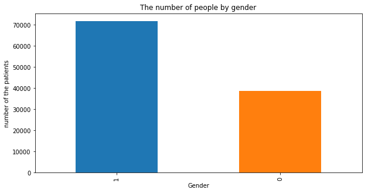

```python
df['genderr'].value_counts().plot(figsize=(10,5),kind='bar')
plt.title('The number of people by gender')
plt.ylabel('number of the patients')
plt.xlabel('Gender')
```

### What is the average age by gender for those attending the appointment ?

```python
show=df.noo_show==True
notshow=df.noo_show==False
```

```python
df.age[show].mean()
```

```
37.790496200732491
```

```python
df.age[notshow].mean()
```

```
34.317666562121957
```

the average age of those who attended their appointment was slightly higher than the average age of those who missed their appointment,reaching 37 years compared to 34 years to who missed.

### What is the most age group that attended the appointment, as well as the most age group that did not attend?

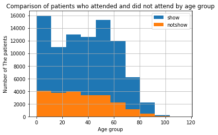

```python
df.age[show].hist(alpha=1,label='show')
df.age[notshow].hist(alpha=1,label='notshow')
plt.title('Comparison of patients who attended and did not attend by age group')
plt.ylabel('Number of The patients')
plt.xlabel('Age group')
plt.legend();
```

### What is the total number of patients who attended the appointment?

```
Text(0.5,0,'Attend')
```

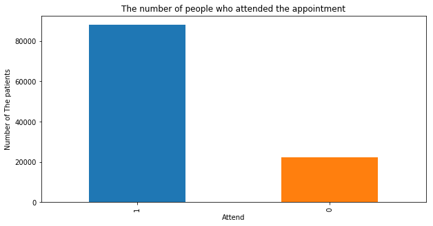

```python
df['noo_show'].value_counts().plot(figsize=(10,5),kind='bar')
plt.title('The number of people who attended the appointment')
plt.ylabel('Number of The patients')
plt.xlabel('Attend')
```

## Conclusions

The average age of those who attended their appointment was slightly higher than the average age of those who missed their appointment,reaching 37 years compared to 34 years to who missed.

The hospital needs to raise the quality of work efficiency and speed of completion in order to reduce the number of patients who missed the appointment.

The data that provides the timing of booking the appointment and the appointment data itself seem illogical, if this data is provided correctly, an analysis of other factors can be provided in the reasons for attending the appointment, such as the efficiency of work in the hospital itself.

No missing or duplicate data, with the data linked with a unified patient identifier correctly.

The age data had an incorrect entry. It was clear that it was the result of a simple error. It was modified by adding the average so that the patient's data could be used.

```python
from subprocess import call
call(['python', '-m', 'nbconvert', 'Investigate_a_Dataset.ipynb'])
```

```
0
```